# Wastewater viral metagenomic analysis

September 10, 2026

# 0. Overview

This report reproduces wastewater viral metagenomics analysis and displays its figures for each step. The genomic data used in this report was selected from the peer-reviewed publication https://journals.asm.org/doi/10.1128/aem.01448-21, including two plants (HTP and PL) from August 2020 through January 2021 and enriched and unenriched sequencing libraries from the same wastewater samples.

The goal is to address five required questions. Each question ends with a review question and answer key. The report is descriptive: sequence detections and variant calls are evidence under the stated criteria, not proof of infectivity, clinical incidence, viral concentration, or biological absence.

# 1. Question 1. Quality control

**Guiding question: How can high duplication and low Q30 interfere with wastewater genomic data interpretation?**

Quality control cleans the raw sequencing data before biological interpretation. Higher Q30 after trimming indicates that retained bases have lower estimated base-calling error. Duplication is shown separately because repeated reads may not provide independent support for rare variants or diversity estimates. Neither measure alone is a biological abundance estimate.

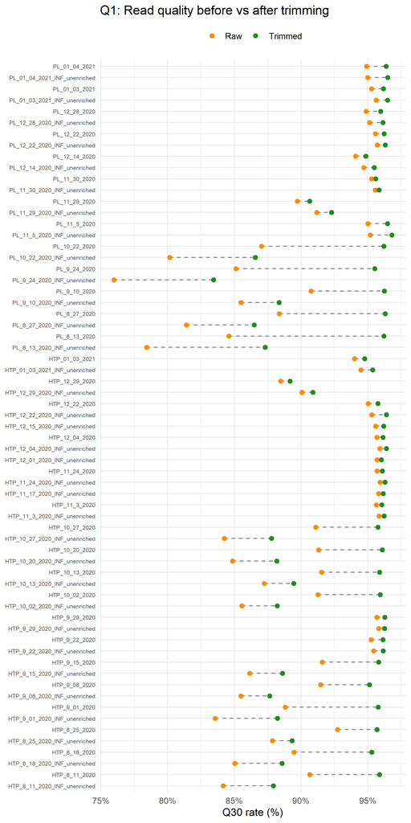

Q1. Read quality before and after trimming: Q30 rate by sample.

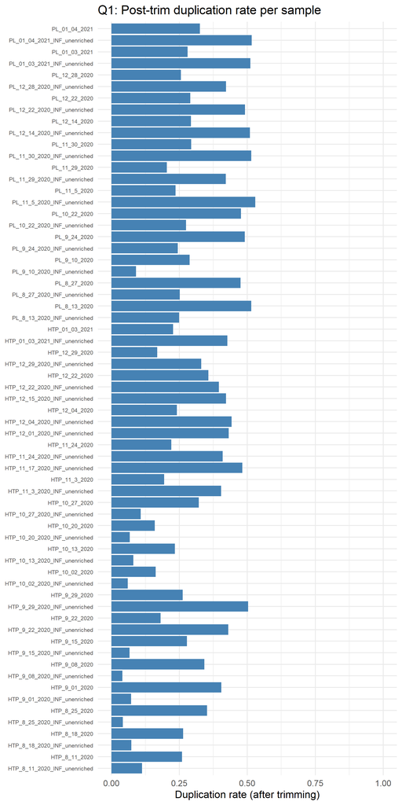

Q1. Post-trim duplication rate by sample.

### Review question

**How can high duplication and low Q30 interfere with interpretation of wastewater genomic data?**

A. They confirm that a virus is abundant and genetically diverse.  
B. They can produce non-independent reads and error-prone base calls, potentially inflating apparent viral diversity or creating false variants.  
C. They prove that the sample contains human contamination.  
D. They affect file size but not biological conclusions.

**Answer**

**B.** High duplication weakens independent support for observations, while low-quality bases can mimic real mutations or viral detections.

# 2. Question 2. Host filtering

**Guiding question: How can human genetic material affect wastewater viral surveillance?**

Host filtering removes human-aligned reads to protect potentially sensitive genetic information and to reduce host background. A larger host-derived fraction leaves less usable sequencing depth for low-abundance nonhuman viruses, so differences in host background can affect surveillance sensitivity.

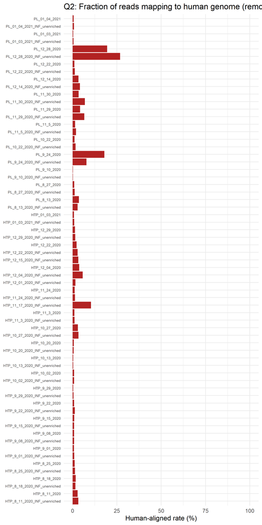

Q2. Fraction of reads mapping to the human genome before removal.

### Review question

**Why can a wastewater sample with a large human-derived read fraction appear to contain fewer respiratory viruses than one with a similar true viral community?**

A. Human-derived reads are more likely to be respiratory viruses.  
B. Host background uses sequencing capacity, reducing sensitivity for low-abundance viral genomes; non-detection may not mean biological absence.  
C. Human reads cause viral genomes to mutate.  
D. Removing human reads increases viral RNA in the original sample.

**Answer**

**B.** Variable host background can create an apparent biological difference when the true issue is analytical sensitivity.

# 3–4. Questions 3–4. Taxonomic classification and abundance over time

## 3. Question 3. Which organisms are present, and why might respiratory viruses not be visible among the dominant taxa?

Taxonomic classification identifies the organisms represented in the sequencing data. The composition plot focuses on matched enrichment status within the same plant/date, reducing temporal and site-related confounding when comparing enrichment. The displayed taxa are the highest-coverage taxa across all paired libraries, and SARS-CoV-2 is retained for visibility if it is not naturally in that set. Therefore, a virus without a visible segment may be present at low abundance or be included in `Other`; the plot cannot establish absence.

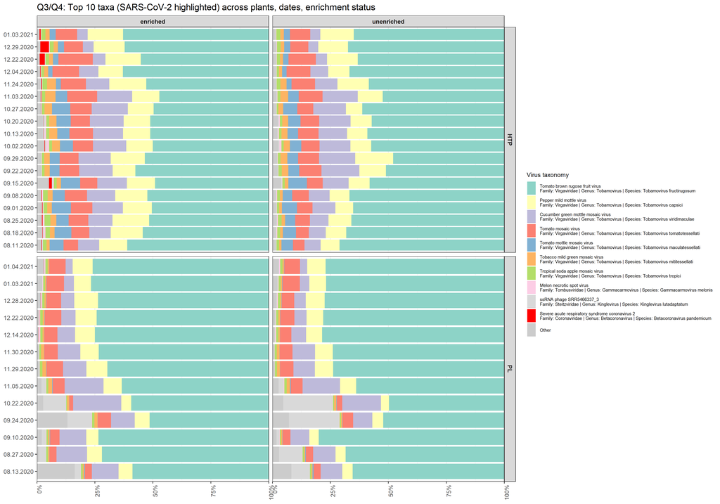

Q3. Top viral taxa by relative coverage across paired enriched and unenriched wastewater libraries.

### Review question

**Why can respiratory viruses be absent from the visible top taxa even when they are present in wastewater?**

A. Their absence from the plot proves no respiratory infections occurred.  
B. Abundant food- and plant-associated viruses can dominate the relative signal, pushing lower-abundance respiratory viruses outside the displayed taxa.  
C. Human-read removal removes respiratory-virus reads.  
D. Enrichment converts respiratory-virus reads into plant-virus reads.

**Answer**

**B.** Relative composition reflects wastewater viral ecology and observed coverage, not necessarily public-health importance.

## 4. Question 4. How do selected viruses appear across sampling dates and enrichment status?

The selected-virus heatmap is the target-specific detection follow-up to the broad composition plot. It evaluates pepper mild mottle virus (a reference control), human norovirus, seasonal human coronaviruses (excluding SARS-CoV-2), human adenovirus, influenza A virus, and SARS-CoV-2 across sampling dates in the same paired libraries. Unlike the relative-composition plot above, the heatmap does not estimate abundance or wastewater concentration.

A colored tile means that at least one matching reference/segment met the predefined read-support criterion in that library. A gray tile means that no matching record met that criterion; it does **not** prove biological absence. The rule does not add several weak reference matches together, and it should not be interpreted as evidence of infectivity or viral concentration.

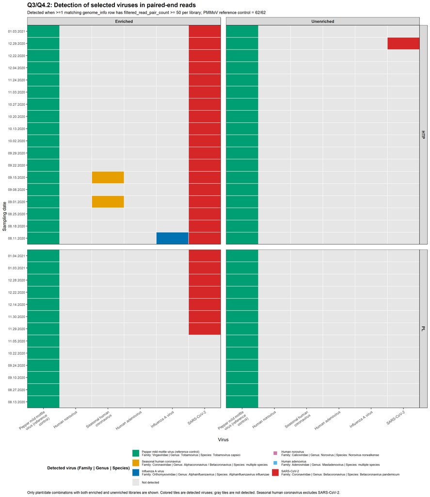

Q4. Targeted detection calls for selected viruses in paired wastewater libraries.

Selected-virus detection summary under the predefined per-reference read-support criterion.

| Virus | Detected libraries | Paired libraries evaluated | Detection rate |
| --- | --- | --- | --- |
| Pepper mild mottle virus (reference control) | 62 | 62 | 100.0% |
| Human norovirus | 0 | 62 | 0.0% |
| Seasonal human coronavirus | 2 | 62 | 3.2% |
| Human adenovirus | 0 | 62 | 0.0% |
| Influenza A virus | 1 | 62 | 1.6% |
| SARS-CoV-2 | 26 | 62 | 41.9% |

### Review question

**If a respiratory virus is not visible in the top-taxa plot, what is the strongest next analysis?**

A. Treat the missing segment as proof of absence.  
B. Examine target-specific, sample-level read support against a predefined detection criterion, including matched enriched and unenriched libraries.  
C. Infer its presence from plant-virus abundance.  
D. Pool all samples until it becomes visible in the composition plot.

**Answer**

**B.** Target-specific analysis separates a virus that is not dominant from one that lacks sufficient evidence for a detection call.

# 5. Question 5. SARS-CoV-2 variants, when sufficient sequence is available

## Detection by sample

The detection plot displays SARS-CoV-2 coverage by sample and labels genome breadth. Samples with at least 50% breadth are eligible for the stringent SNV analysis; this breadth criterion helps avoid interpreting variation from genomes observed only in small fragments.

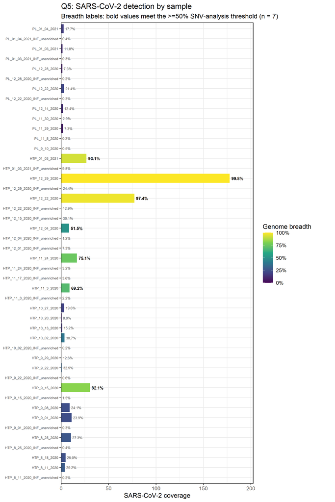

Q5. SARS-CoV-2 coverage and genome breadth by sample.

```
## The stringent SNV analysis includes 7 of 46 SARS-CoV-2 sample summaries that meet the genome-breadth criterion.
```

## High-frequency SNVs and genome context

High-frequency SNV calls are distinct position/change events from the high-breadth sample set. The table panel retains eligible samples with zero such calls, and the genome map groups calls by genomic position/change and annotates their open reading frame. These calls are descriptive because the script does not apply a separate per-site sequencing-depth cutoff.

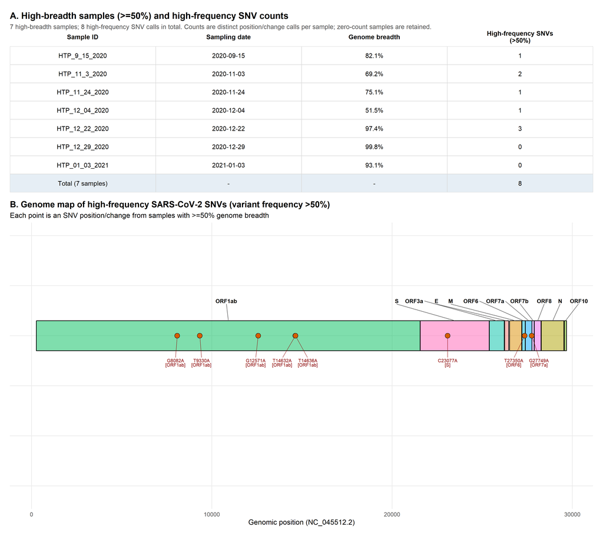

Q5. Eligible samples, high-frequency SNV counts, and genomic locations.

## Temporal variation and ORF burden

The temporal-variability plot uses **all** observed SNVs from high-breadth samples. For each plant/date/position, it averages variant frequency and ranks positions by variation across dates. It is intentionally different from the high-frequency analysis, which asks whether a variant dominates within an individual sample. Missing observations are not treated as zero.

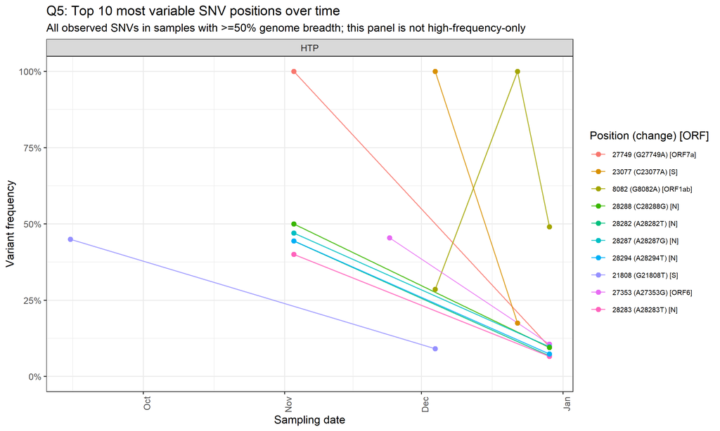

Q5. The most variable SARS-CoV-2 SNV positions over time.

The ORF panel counts distinct high-frequency positions by plant, date, and open reading frame. It is a count of qualifying calls, not an estimate of total viral burden or evidence of functional selection.

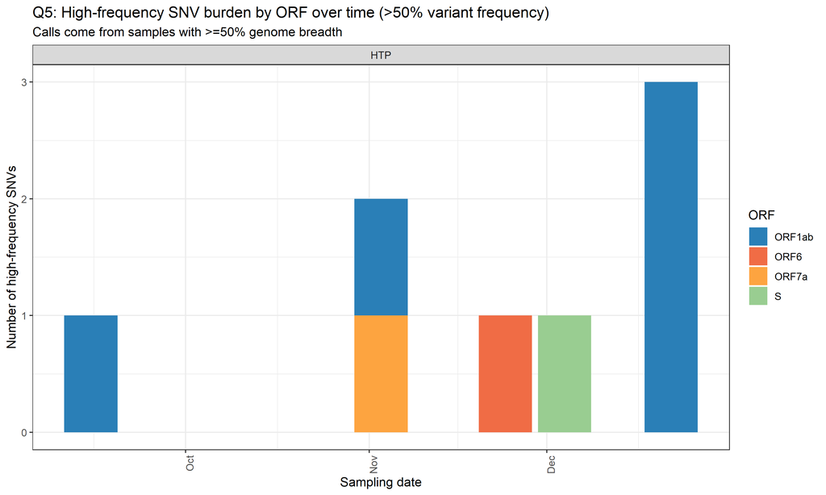

Q5. High-frequency SARS-CoV-2 SNV counts by open reading frame over time.

### Review question

**Why can SARS-CoV-2 SNVs that vary most across sampling dates differ from SNVs that are high frequency within individual samples?**

A. The two groups should always be identical if the data are valid.  
B. Temporal variability measures change between dates, while high frequency measures within-sample predominance; a mutation may fluctuate without becoming dominant, or remain dominant with little temporal change.  
C. High-frequency SNVs occur only in noncoding regions.  
D. Any temporally variable SNV necessarily reflects functional selection.

**Answer**

**B.** The figures describe different properties of the wastewater viral population: longitudinal change versus within-sample dominance.

# Reproducibility and companion outputs

To regenerate the companion PNG and TSV outputs, run the companion analysis script before rendering this report. The companion tables include the top-taxa taxonomy table, selected-virus detection calls and summary, SARS-CoV-2 sample summary, stringent SNV table, annotated SNV table, and high-frequency SNV tables.

Interpret trends conservatively: reference-based detection can be affected by mapping specificity and sequencing depth, enrichment can change analytical sensitivity without proving a higher wastewater concentration, and wastewater sequence data alone do not identify individual infections or viral infectivity.

# Brief results summary

After trimming, duplicate reads were observed; the downstream viral results used for the next analytical steps were deduplicated before interpretation. Plant-associated viruses dominated the paired-library composition, while target-specific analysis detected SARS-CoV-2 more often than the other selected respiratory viruses and detected the pepper mild mottle virus reference control in every paired library. Only a small high-breadth SARS-CoV-2 subset supported SNV analysis, so the observed variant patterns are descriptive rather than evidence of lineage prevalence or functional selection.